# Prosper Loan Data Exploration

## By Donnelly Miller

## Prosper loan investigation goal

Borrowing money seems to be a way of life for many people. There are many reasons borrowers will request a loan. When it comes to borrowing money, many factors can potentially affect the outcome of the loan. The main goal is to pay off the debt by incurring as extra debt as possible. Unfortunately, not all loans are paid on time, and some are charged off or defaulted on. The goal of this investigation is to examine the relationships between variables that may suggest increased ore decreases risks in a borrower's ability to pay back a loan. A large part of repaying back a loan involves paying interest on top of the original loan amount. Another goal of this investigation is to determine what factors might contribute to paying lower interest and how in turn this might affect the status of the loan. How might factors that contribute to both interest rate and loan status be related? This investigation will address two questions.

### Primary question to be investigated: What factors might contribute to the status of a loan?

### Secondary question to be investigated: What factors might contribute to a higher interest rate?

The process begins by doing some univariate data exploration. Following the univariate exploration, the following sets of slides focus on the bivariate aspect and finally concluding with the multivariate exploration where we get some insights on to the possible risk factors for higher interests' rates and negative loan statuses.

#### Variables that might be worth investigating to address the questions:

- Credit score
- Number of open credit lines
- Income
- Employment status
- Term length of the loan
- Interest rate
- Debt to income ratio
- Prosper score
- Original loan amount
- Required montly payment

## Updated Dataset Structure

There is information on 113,937 loans on this dataset. Several variables are associated with this dataset some of which include credit scores, employment status, income, number of open credit lines, occupation, and current delinquencies. There are several both numeric and categorical variables. Some of the categorical variables have been ordered.

The following bar graph displays in order, from greatest to least, the reasons why borrowers requests loans. Debt consolidation ranks the top reason for requesting loans.

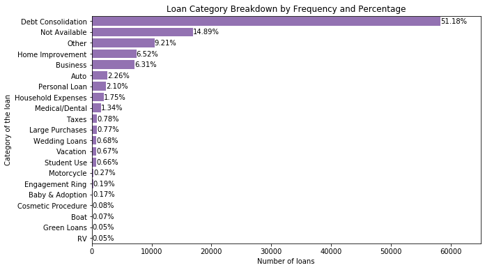

```python
# Setting up a horizontal bar chart with each bar labeled with the percentage
plt.figure(figsize = (10, 6))
sn.countplot(data = df_loan, y = 'LoanReason', order = type_order1, color = base_color)

for i in range(type_count1.shape[0]):
    count = type_count1[i]
    pct_string = '{:0.2f}%'.format(100 * count/n_df)
    plt.text(count + 1, i, pct_string, va = 'center')
    plt.xlim(0, 65000)
    plt.xlabel('Number of loans')
    plt.ylabel('Category of the loan')
    plt.title('Loan Category Breakdown by Frequency and Percentage');
```

The following horizontal bar chart shows that most loans are current or completed, but a large number of loans are charged off or go into default.

```
0.4965551137909546
```

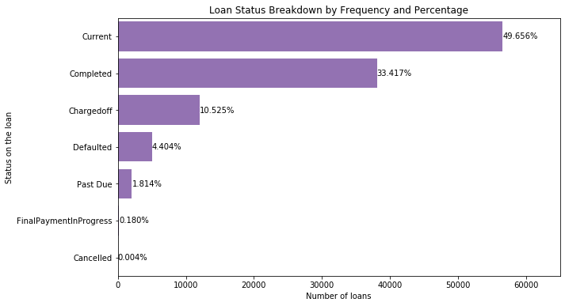

```python
# Plotting the the bar graph with the updated LoanStatus column
type_counts = df_loan.LoanStatus.value_counts()
type_order = type_counts.index
max_type_count = type_counts[0]
max_prop = max_type_count/n_df
print(max_prop)

plt.figure(figsize = (10, 6))
sn.countplot(data = df_loan, y = 'LoanStatus', order = type_order, color = base_color)

for i in range(type_counts.shape[0]):
    count = type_counts[i]
    pct_string = '{:0.3f}%'.format(100 * count/n_df)
    plt.text(count + 1, i, pct_string, va = 'center')
    plt.xlim(0, 65000)
    plt.xlabel('Number of loans')
    plt.ylabel('Status on the loan')
    plt.title('Loan Status Breakdown by Frequency and Percentage');
```

The following histogram shows the distribution of lower credit score ranges, with most lower credit score ratings falling between 650 and 750.

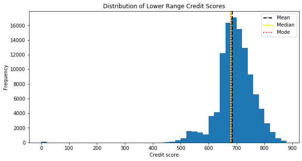

```python
# Detailed histogram of the lower credit score range with measures of central tendency
mean_credit_lower_range = df_loan.CreditScoreRangeLower.mean()
median_credit_lower_range = df_loan.CreditScoreRangeLower.median()
mode_credit_lower_range = df_loan.CreditScoreRangeLower.value_counts().nlargest(1).index[0]
plt.figure(figsize = (10, 5))
bin_edges = np.arange(0, df_loan.CreditScoreRangeLower.max()+20, 20)
plt.hist(data = df_loan, x = 'CreditScoreRangeLower', bins = bin_edges);
plt.axvline(mean_credit_lower_range, color='black', linestyle='dashed', linewidth=2)
plt.axvline(median_credit_lower_range, color = 'yellow', linewidth = 2)
plt.axvline(mode_credit_lower_range, color = 'red', linestyle = 'dotted', linewidth = 2)
plt.xlabel('Credit score')
plt.ylabel('Frequency')
plt.title('Distribution of Lower Range Credit Scores')
plt.xticks(np.arange(0, 1000, 100))
plt.legend({'Mean': mean_credit_lower_range, 'Median':median_credit_lower_range, 'Mode': mode_credit_lower_range});
```

The following histogram shows the distribution of upper credit score ranges, with most upper credit score ratings falling between 650 and 750.

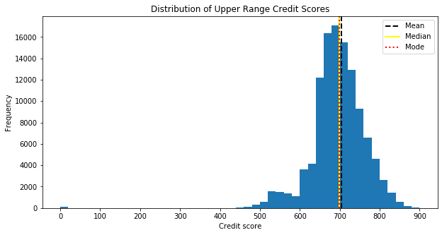

```python
# Detailed histogram of the upper credit score range with measures of central tendency
mean_credit_upper_range = df_loan.CreditScoreRangeUpper.mean()
median_credit_upper_range = df_loan.CreditScoreRangeUpper.median()
mode_credit_upper_range = df_loan.CreditScoreRangeUpper.value_counts().nlargest(1).index[0]
plt.figure(figsize = (10, 5))
bin_edges = np.arange(0, df_loan.CreditScoreRangeUpper.max()+20, 20)
plt.hist(data = df_loan, x = 'CreditScoreRangeUpper', bins = bin_edges);
plt.axvline(mean_credit_upper_range, color='black', linestyle='dashed', linewidth=2)
plt.axvline(median_credit_upper_range, color = 'yellow', linewidth = 2)
plt.axvline(mode_credit_upper_range, color = 'red', linestyle = 'dotted', linewidth = 2)
plt.xlabel('Credit score')
plt.ylabel('Frequency')
plt.title('Distribution of Upper Range Credit Scores')
plt.xticks(np.arange(0, 1000, 100))
plt.legend({'Mean': mean_credit_upper_range, 'Median':median_credit_upper_range, 'Mode': mode_credit_upper_range});
```

The following bar chart shows the income ranges from highest to lowest in frequency.

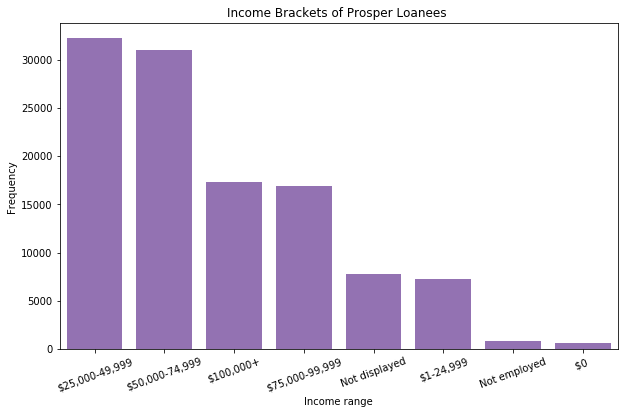

```python
# Looking at the income range of those taking out loans
gen_order2 = df_loan['IncomeRange'].value_counts().index
plt.figure(figsize = (10, 6))
sn.countplot(data = df_loan, x = 'IncomeRange', color = base_color, order = gen_order2)
plt.xticks(rotation = 20)
plt.ylabel('Frequency')
plt.xlabel('Income range')
plt.title('Income Brackets of Prosper Loanees ');
```

Prosper ratings are used to allow potential investors to consider the loan application and the possible estimated average annual loss rate. A Prosper rating of AA presents the lowest risk, with HR posing as the greatest risk. The sequential order of risk level from greatest to least (NC, HR, E, D, C, B, A, AA). Note that for Credit Grade there is an NC for loans originating prior to 2009.

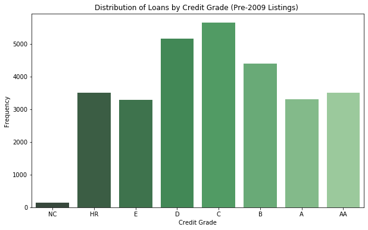

```python
# Plotting the credit grade for loans originating prior to 2009
plt.figure(figsize = (10, 6))
sn.countplot(data = df_loan, x = 'CreditGrade', palette = 'Greens_d')
plt.ylabel('Frequency')
plt.xlabel('Credit Grade')
plt.title('Distribution of Loans by Credit Grade (Pre-2009 Listings) ');
```

The following bar chart is for alpha credit ratings after July 2009 following the same rating format as for those pre-2009.

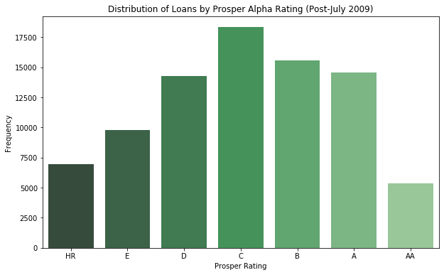

```python
# Plotting the prosper rating (applicable to loans originating after July 2009)
plt.figure(figsize = (10, 6))
sn.countplot(data = df_loan, x = 'ProsperRating', palette = 'Greens_d')
plt.ylabel('Frequency')
plt.xlabel('Prosper Rating')
plt.title('Distribution of Loans by Prosper Alpha Rating (Post-July 2009)');
```

The following bar chart shows many Prosper scores (numeric) fall within the 4 to 8 range.

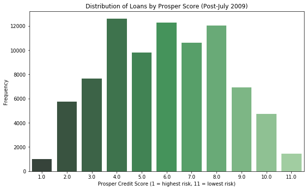

```python
mean_score = df_loan.ProsperScore.mean()
median_score = df_loan.ProsperScore.median()
plt.figure(figsize = (10, 6))
sn.countplot(data = df_loan, x = 'ProsperScore', palette = 'Greens_d')
plt.ylabel('Frequency')
plt.xlabel('Prosper Credit Score (1 = highest risk, 11 = lowest risk)')
plt.title('Distribution of Loans by Prosper Score (Post-July 2009)');
```

The following histogram depicts the wide range of borrower's debt-to-income ratios with a peak at around 20-24%.

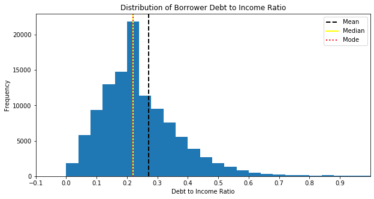

```python
mean_debt_to_income_ratio = df_loan.DebtToIncomeRatio.mean()
median_debt_to_income_ratio = df_loan.DebtToIncomeRatio.median()
mode_debt_to_income_ratio = df_loan.DebtToIncomeRatio.value_counts().nlargest(1).index[0]
plt.figure(figsize = (10, 5))
bin_edges = np.arange(df_loan.DebtToIncomeRatio.min(), df_loan.DebtToIncomeRatio.max()+ .04, .04)
plt.hist(data = df_loan, x = 'DebtToIncomeRatio', bins = bin_edges);
plt.axvline(mean_debt_to_income_ratio, color='black', linestyle='dashed', linewidth=2)
plt.axvline(median_debt_to_income_ratio, color = 'yellow', linewidth = 2)
plt.axvline(mode_debt_to_income_ratio, color = 'red', linestyle = 'dotted', linewidth = 2)
plt.xticks(np.arange(-.1, 1.0, .1))
plt.xlim(-.1, 1, .1)
plt.xlabel('Debt to Income Ratio')
plt.ylabel('Frequency')
plt.title('Distribution of Borrower Debt to Income Ratio')
plt.legend({'Mean': mean_debt_to_income_ratio, 'Median':median_debt_to_income_ratio, 'Mode': mode_debt_to_income_ratio});
```

The following histogram shows that most borrowers had interest rates falling between 8% to 26%.

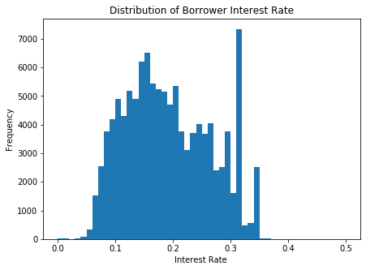

```python
plt.figure(figsize = (7, 5))
bin_edges2 = np.arange(df_loan.BorrowerRate.min(), df_loan.BorrowerRate.max() +.01, .01)
sn.distplot(df_loan.BorrowerRate, bins = bin_edges2, kde = False, hist_kws = {'alpha': 1})
plt.ylabel('Frequency')
plt.xlabel('Interest Rate ')
plt.title('Distribution of Borrower Interest Rate');
```

The distribution of open credit lines shows that many borrowers had between five and ten open credit lines, with some borrowers having as many as 30 or more.

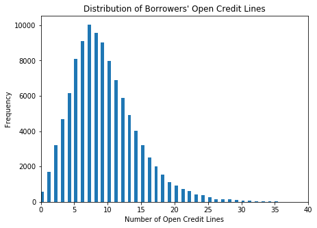

```python
# Some very small changes to the mean and standard deviation
# plotting the frequencies of open credit lines
plt.figure(figsize = (7, 5))
bin_edges3 = np.arange(df_loan.OpenCreditLines.min(), df_loan.OpenCreditLines.max() +.5, .5)
sn.distplot(df_loan.OpenCreditLines, bins = bin_edges3, kde = False, hist_kws = {'alpha': 1})
plt.xlim(0, 40) # Can zone in more on the distribution without the outlier at 54
plt.ylabel('Frequency')
plt.xlabel('Number of Open Credit Lines')
plt.title("Distribution of Borrowers' Open Credit Lines");
```

The following bar graph groups employment status from the most to least occurring.

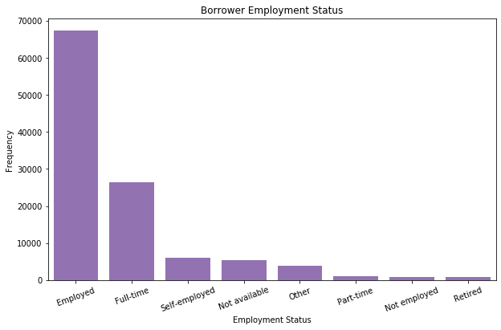

```python
gen_order3 = df_loan['EmploymentStatus'].value_counts().index
plt.figure(figsize = (10, 6))
sn.countplot(data = df_loan, x = 'EmploymentStatus', color = base_color, order = gen_order3)
plt.xticks(rotation = 20)
plt.ylabel('Frequency')
plt.xlabel('Employment Status')
plt.title('Borrower Employment Status');
```

The donut plot show that over three quarters of the originating loan amounts were for a term of 36 months.

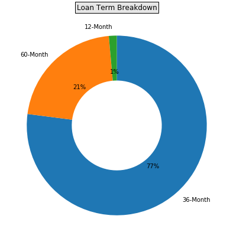

```python
plt.figure(figsize = (7,7))
sorted_counts = df_loan.Term.value_counts()
plt.pie(sorted_counts, labels = sorted_counts.index, startangle = 90, counterclock= False, autopct='%.1d%%', \
       wedgeprops = {'width' : 0.5})
plt.title('Loan Term Breakdown', bbox={'facecolor':'.9', 'pad':3});
```

The following histogram shows most original loan amounts were for under $10,000. Many loans were for amounts of $15,000 or greater, with some loans as much as $25,000 or more.

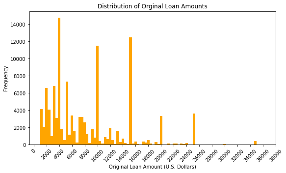

```python
plt.figure(figsize = (9, 5))
binsize = 400
bin_edges5 = np.arange(df_loan.LoanOriginalAmount.min(), df_loan.LoanOriginalAmount.max() + binsize, binsize)
sn.distplot(df_loan.LoanOriginalAmount, bins = bin_edges5, kde = False, color = 'orange', hist_kws = ({'alpha': 1}))
plt.ylabel('Frequency')
plt.xlabel('Original Loan Amount (U.S. Dollars)')
plt.xticks(np.arange(0, 40000, 2000), rotation = 45)
plt.title('Distribution of Orginal Loan Amounts');
```

The following histogram shows the distribution of monthly payments. Most scheduled monthly payments were under $500.

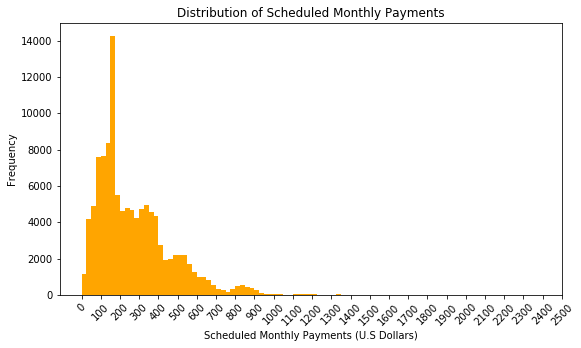

```python
# Plotting the monthly payment distribution
plt.figure(figsize = (9, 5))
binsize2 = 25
bin_edges6 = np.arange(df_loan.MonthlyLoanPayment.min(), df_loan.MonthlyLoanPayment.max() + binsize2, binsize2)
sn.distplot(df_loan.MonthlyLoanPayment, bins = bin_edges6, kde = False, color = 'orange', hist_kws = {'alpha': 1})
plt.xticks(np.arange(0, 2501, 100), rotation = 45)
plt.ylabel('Frequency')
plt.xlabel('Scheduled Monthly Payments (U.S Dollars)')
plt.title('Distribution of Scheduled Monthly Payments');
```

The following heatmap shows there is a strong correlation between original loan amount and scheduled monthly payment. There were also moderate correlations between both credit scores and Prosper scores and borrower's interests' rates.

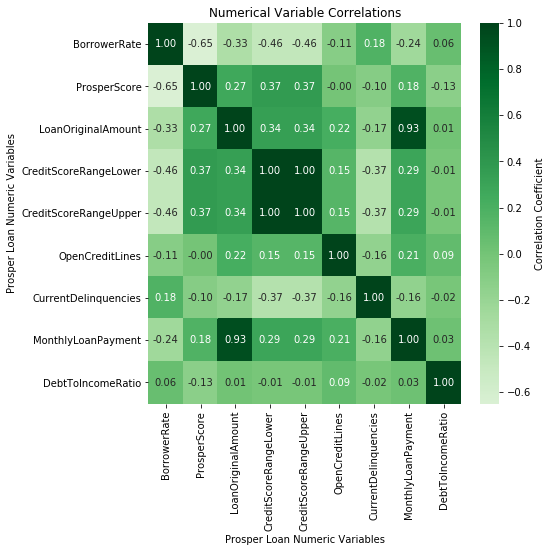

```python
# Using a heatmap to plot the correlations with annotations
# Begin by creating a list of the numerical variables to be compared with one another
num_vars = ['BorrowerRate', 'ProsperScore', 'LoanOriginalAmount', 'CreditScoreRangeLower', 'CreditScoreRangeUpper', \
           'OpenCreditLines', 'CurrentDelinquencies', 'MonthlyLoanPayment', 'DebtToIncomeRatio']
plt.figure(figsize = (7, 7))
sn.heatmap(df_loan[num_vars].corr(), annot = True, fmt = '.2f', cmap = 'Greens', center = 0, \
           cbar_kws = {'label': 'Correlation Coefficient'})
plt.xlabel('Prosper Loan Numeric Variables')
plt.ylabel('Prosper Loan Numeric Variables')
plt.title('Numerical Variable Correlations');
```

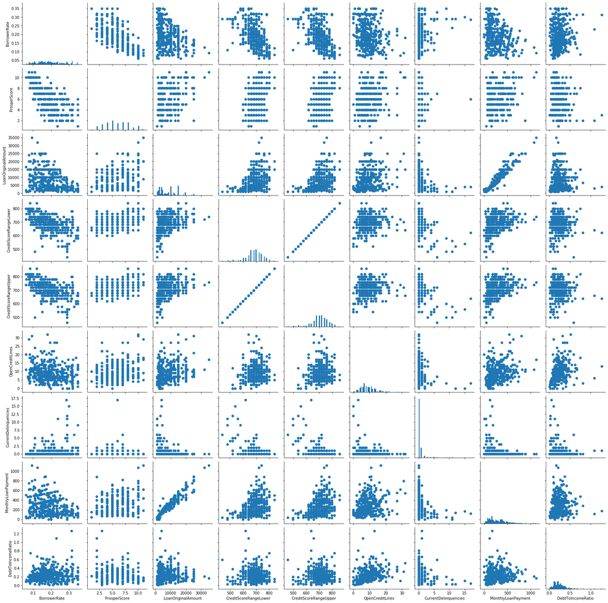

```python
# Plotting a matrix of pairwise correlations by using a sample of 400 loans
# Use of a smaller sample size from the dataset reduces excessive overlap of data points
sample1 = np.random.choice(df_loan.shape[0], 400, replace = False)
loans_sample = df_loan.loc[sample1,:]
g = sn.PairGrid(data = loans_sample, vars = num_vars)
g = g.map_diag(plt.hist, bins = 50)
g.map_offdiag(plt.scatter);
```

The following is both a scatterplot and heatmap showing the correlation between upper credit score ranges and borrower interests' rates. The heatmap gives a better visual on how higher credit scores are moderately correlated with reduced interests' rates.

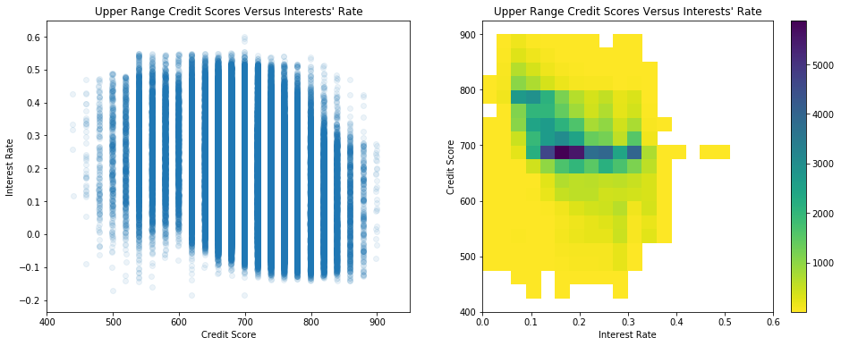

```python
plt.figure(figsize = (16, 6))
plt.subplot(1, 2, 1)
sn.regplot(data = df_loan, x = 'CreditScoreRangeUpper', y = 'BorrowerRate', fit_reg = False, x_jitter = 0.5, y_jitter = 0.2, \
          scatter_kws = {'alpha':1/12})
plt.xlim(400, 950)
plt.xlabel('Credit Score')
plt.ylabel('Interest Rate')
plt.title( "Upper Range Credit Scores Versus Interests' Rate");

plt.subplot(1, 2, 2)
bins_x = np.arange(0, df_loan.BorrowerRate.max() + 0.5, 0.03)
bins_y = np.arange(400, df_loan.CreditScoreRangeUpper.max() + 50, 25)
plt.hist2d(data = df_loan, x = 'BorrowerRate', y = 'CreditScoreRangeUpper', bins = [bins_x, bins_y], cmap = 'viridis_r', \
           cmin = 0.5);
plt.xlim(0, 0.6)
plt.ylabel('Credit Score')
plt.xlabel('Interest Rate')
plt.title("Upper Range Credit Scores Versus Interests' Rate")
plt.colorbar();
```

Between the scatterplot and heatmap, the heatmap visually shows how there is a moderate to almost strong negative correlation between Prosper scores and borrower interest rates as noted by the darkened regions.

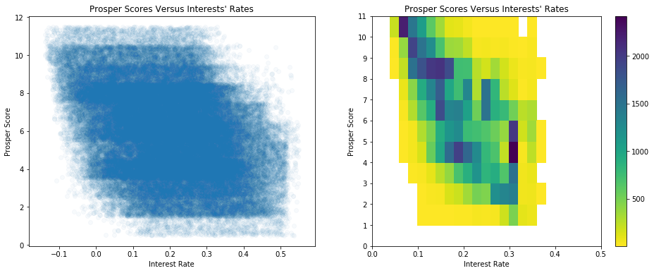

```python
plt.figure(figsize = (16, 6))
plt.subplot(1, 2, 1)
sn.regplot(data = df_loan, x = 'BorrowerRate', y = 'ProsperScore', fit_reg = False, x_jitter = 0.2, \
           y_jitter = 0.5, scatter_kws = {'alpha':0.03})
plt.xlabel('Interest Rate')
plt.ylabel('Prosper Score')
plt.title( "Prosper Scores Versus Interests' Rates");

plt.subplot(1, 2, 2)
bins_x2 = np.arange(0, df_loan.BorrowerRate.max() + 0.5, .02)
bins_y2 = np.arange(0, df_loan.ProsperScore.max() +1, 1)
plt.hist2d(data = df_loan, x = 'BorrowerRate', y = 'ProsperScore', bins = [bins_x2, bins_y2], cmap = 'viridis_r', \
           cmin = 0.5);
plt.yticks(np.arange(0, 12, 1))
plt.xlim(0, 0.5)
plt.xlabel('Interest Rate')
plt.ylabel('Prosper Score')
plt.title("Prosper Scores Versus Interests' Rates")
plt.colorbar();
```

The following violin and boxplots show the distribution of upper credit score ranges for each of the loan statuses. Higher credit scores appear to be a good indicator of reduced risk.

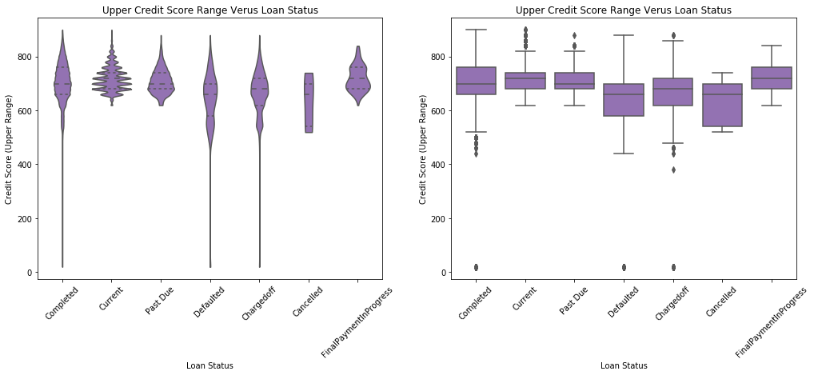

```python
plt.figure(figsize = (17, 6))
plt.subplot(1, 2, 1)
violinplot(df_loan.LoanStatus, df_loan.CreditScoreRangeUpper)
plt.xticks(rotation = 45)
plt.xlabel('Loan Status')
plt.ylabel('Credit Score (Upper Range)')
plt.title('Upper Credit Score Range Verus Loan Status');

plt.subplot(1, 2, 2)
box_plot(df_loan.LoanStatus, df_loan.CreditScoreRangeUpper)
plt.xticks(rotation = 45)
plt.xlabel('Loan Status')
plt.ylabel('Credit Score (Upper Range)')
plt.title('Upper Credit Score Range Verus Loan Status');
```

Debt-to-income ratio does not appear to have any effect on determining a borrower's risk as shows by the following violin and boxplots.

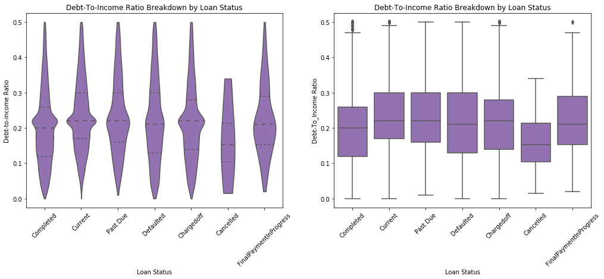

```python
plt.figure(figsize = (17, 6))
plt.subplot(1, 2, 1)
violinplot(df_loan2.LoanStatus, df_loan2.DebtToIncomeRatio)
plt.xticks(rotation = 45)
plt.xlabel('Loan Status')
plt.ylabel('Debt-to-income Ratio')
plt.title('Debt-To-Income Ratio Breakdown by Loan Status');

plt.subplot(1, 2, 2)
box_plot(df_loan2.LoanStatus, df_loan2.DebtToIncomeRatio)
plt.xticks(rotation = 45)
plt.xlabel('Loan Status')
plt.ylabel('Debt-To_Income Ratio')
plt.title('Debt-To-Income Ratio Breakdown by Loan Status');
```

The following violin and boxplots visually show there may be reduced risk in borrowers with higher Prosper scores.

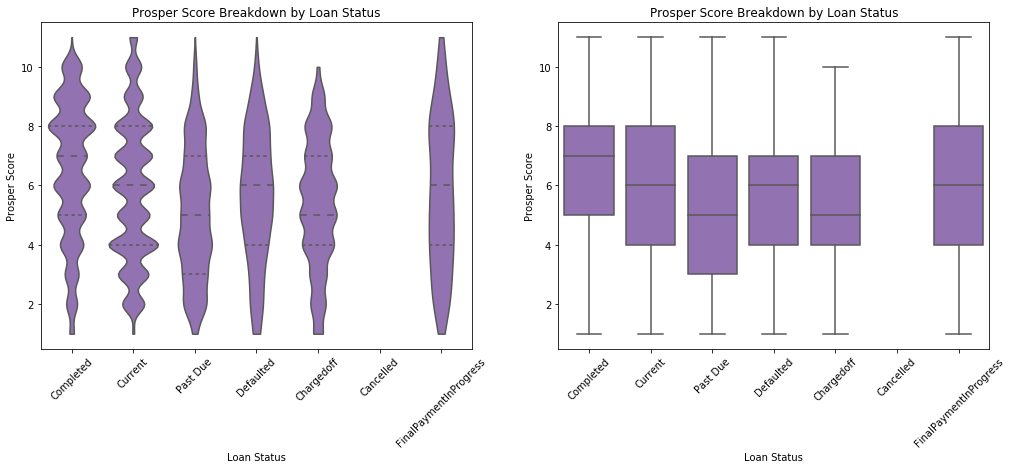

```python
plt.figure(figsize = (17, 6))
plt.subplot(1, 2, 1)
violinplot(df_loan.LoanStatus, df_loan.ProsperScore)
plt.xticks(rotation = 45)
plt.xlabel('Loan Status')
plt.ylabel('Prosper Score')
plt.title('Prosper Score Breakdown by Loan Status');

plt.subplot(1, 2, 2)
box_plot(df_loan.LoanStatus, df_loan.ProsperScore)
plt.xticks(rotation = 45)
plt.xlabel('Loan Status')
plt.ylabel('Prosper Score')
plt.title('Prosper Score Breakdown by Loan Status');
```

The following boxplots show that completed loans had about the same average of scheduled monthly payment amounts as loans that were defaulted or charged off. A similar pattern was observed when looking at original loan amounts. There does not seem to be any indication of increased risk of loans being charged off or defaulted on based on these two variables.

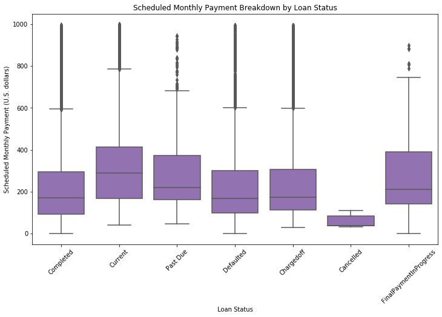

```python
plt.figure(figsize = (12, 7))
box_plot(df_loan3.LoanStatus, df_loan3.MonthlyLoanPayment)
plt.xticks(rotation = 45)
plt.xlabel('Loan Status')
plt.ylabel('Scheduled Monthly Payment (U.S. dollars)')
plt.title('Scheduled Monthly Payment Breakdown by Loan Status');
```

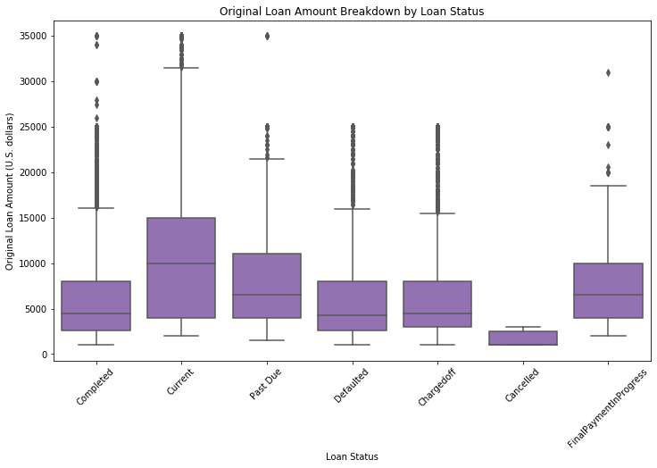

```python
# Plotting original loan amount
plt.figure(figsize = (12, 7))
box_plot(df_loan.LoanStatus, df_loan.LoanOriginalAmount)
plt.xticks(rotation = 45)
plt.xlabel('Loan Status')
plt.ylabel('Original Loan Amount (U.S. dollars)')
plt.title('Original Loan Amount Breakdown by Loan Status');
```

Borrowers in higher income brackets on average have higher Prosper scores based on the following boxplot.

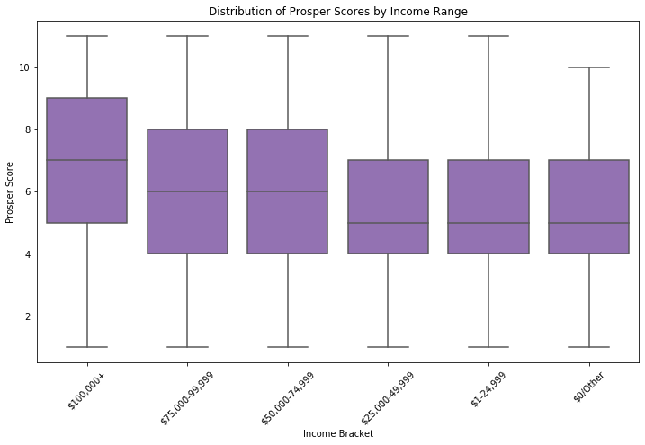

```python
plt.figure(figsize = (12, 7))
box_plot(df_loan.IncomeRange, df_loan.ProsperScore)
plt.xticks(rotation = 45)
plt.xlabel('Income Bracket')
plt.ylabel('Prosper Score')
plt.title('Distribution of Prosper Scores by Income Range');
```

The following clustered bar chart provides a breakdown of the term lengths by loan status.

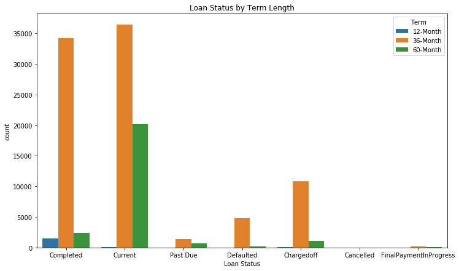

```python
# Clustered bar chart between the two variables
plt.figure(figsize = (12, 7))
sn.countplot(data = df_loan, x = 'LoanStatus', hue = 'Term')
plt.xlabel('Loan Status')
plt.title('Loan Status by Term Length');
```

The following clustered bar chart shows loan status by income range.

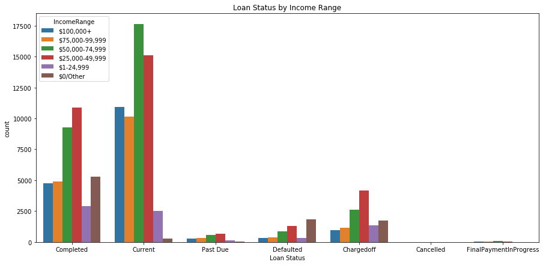

```python
plt.figure(figsize = (15, 7))
sn.countplot(data = df_loan, x = 'LoanStatus', hue = 'IncomeRange')
plt.xlabel('Loan Status')
plt.title('Loan Status by Income Range');
```

The following heatmap shows the statuses of loans by income range. It is more clearly shown borrowers in the $25k to $75 range make up the greatest count loans that are current.

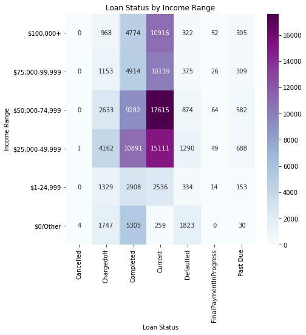

```python
# Generating a heatmap with the same two variables investigated above
# Summarizing the counts into a matrix to be used for plotting
ct_counts = df_loan.groupby(['LoanStatus', 'IncomeRange']).size()
ct_counts = ct_counts.reset_index(name = 'count')
ct_counts = ct_counts.pivot(index = 'IncomeRange', columns = 'LoanStatus', values = 'count')

# Plotting the heatmap
plt.figure(figsize = (7, 7))
mask = ct_counts.isnull()
sn.heatmap(ct_counts, annot = True, fmt = 'd', mask = mask, cmap = 'BuPu')
plt.xlabel('Loan Status')
plt.ylabel('Income Range')
plt.title('Loan Status by Income Range');
```

The horizontal clustered bar chart representing credit ratings post July 2009 demonstrate that higher credit ratings may indicate reduced risk of a loan going into default or ending up in a charged off status.

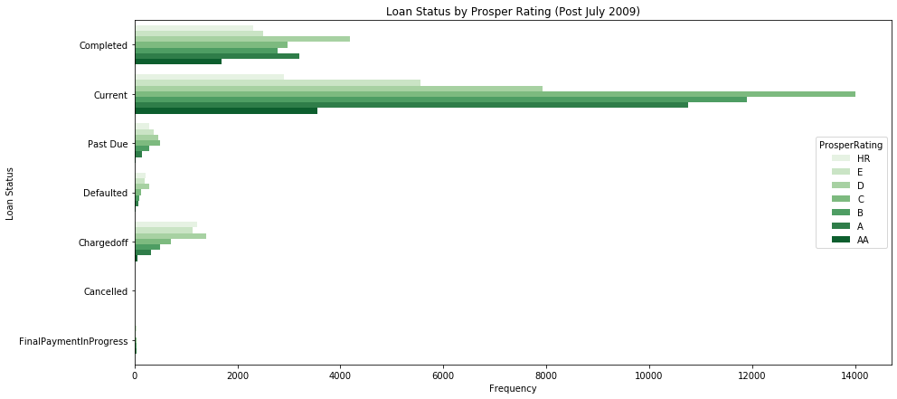

```python
plt.figure(figsize = (15, 7))
sn.countplot(data = df_loan, y = 'LoanStatus', hue = 'ProsperRating', palette = 'Greens')
plt.xlabel('Frequency')
plt.ylabel('Loan Status')
plt.title('Loan Status by Prosper Rating (Post July 2009)');
```